# San Francisco Crime Data Mining Project

Arash, Mike, Russell

May 14, 2016

### Project Summary

This is the final group project for Data Mining (CST495). We are going to use San Francisco crime data to predict how dangerous it is to be in different locations during different times. We are going to look at the data from 911 calls. Dataset has a number of features but we are going to mostly use Police District, Time of day, Day of week and Type of crime (is it violent or not).

### Loading requiered libraries and resources

```r
library(rpart)
library(rpart.plot)
library(e1071)
library(rgdal)
library(ggplot2)
library(RColorBrewer)
library(rgeos)
```

# Data Acquisition

```r
rawData = read.csv("/Users/wiseR3B3L/Documents/CS/R Projects/crimedata/crimetableset.csv")
SFMap = readOGR("/Users/wiseR3B3L/Downloads/Historic Police Districts/","SFPD")
```

# Data Exploration

We need to explore the data to have a better understanding about the data that we are working with. We have prepared different plot and heat maps to display how scattered is our data in different neighborhoods.

### Dataset Structure and Summary

```r
str(rawData)
```

```
## 'data.frame':    76175 obs. of  9 variables:
##  $ Dates     : Factor w/ 33229 levels "1/10/15 0:01",..: 20187 20187 20186 20185 20185 20185 20185 20185 20184 20184 ...
##  $ Category  : Factor w/ 37 levels "ARSON","ASSAULT",..: 36 22 22 17 17 17 35 35 17 17 ...
##  $ Descript  : Factor w/ 662 levels "ABANDONMENT OF CHILD",..: 653 613 613 305 305 307 555 555 305 305 ...
##  $ DayOfWeek : Factor w/ 7 levels "Friday","Monday",..: 7 7 7 7 7 7 7 7 7 7 ...
##  $ PdDistrict: Factor w/ 10 levels "BAYVIEW","CENTRAL",..: 5 5 5 5 6 3 3 1 7 2 ...
##  $ Resolution: Factor w/ 16 levels "ARREST, BOOKED",..: 1 1 1 12 12 12 12 12 12 12 ...
##  $ Address   : Factor w/ 12867 levels "0 Block of 10TH ST",..: 11357 11357 12646 2680 1066 848 8319 10530 7153 10354 ...
##  $ X         : num  -122 -122 -122 -122 -122 ...
##  $ Y         : num  37.8 37.8 37.8 37.8 37.8 ...
```

```r
summary(rawData)
```

```
##             Dates                 Category
##  10/1/14 12:00 :   25   LARCENY/THEFT :20438
##  2/20/15 0:01  :   25   OTHER OFFENSES: 9997
##  4/1/15 0:01   :   25   NON-CRIMINAL  : 9616
##  6/1/14 0:01   :   25   ASSAULT       : 6553
##  3/17/15 12:00 :   24   VEHICLE THEFT : 3868
##  10/18/14 12:00:   23   VANDALISM     : 3623
##  (Other)       :76028   (Other)       :22080
##                                   Descript         DayOfWeek
##  GRAND THEFT FROM LOCKED AUTO         : 8520   Friday   :11497
##  DRIVERS LICENSE, SUSPENDED OR REVOKED: 2589   Monday   :10840
##  STOLEN AUTOMOBILE                    : 2525   Saturday :11173
##  AIDED CASE, MENTAL DISTURBED         : 2388   Sunday   :10296
##  PETTY THEFT OF PROPERTY              : 2327   Thursday :10238
##  LOST PROPERTY                        : 2317   Tuesday  :10833
##  (Other)                              :55509   Wednesday:11298
##      PdDistrict                Resolution
##  SOUTHERN :14767   NONE             :51592
##  NORTHERN : 9458   ARREST, BOOKED   :17254
##  MISSION  : 9298   ARREST, CITED    : 3058
##  CENTRAL  : 9296   PSYCHOPATHIC CASE: 1143
##  BAYVIEW  : 6891   UNFOUNDED        : 1066
##  INGLESIDE: 6618   LOCATED          :  945
##  (Other)  :19847   (Other)          : 1117
##                      Address            X                Y
##  800 Block of BRYANT ST  : 2277   Min.   :-122.5   Min.   :37.71
##  800 Block of MARKET ST  :  688   1st Qu.:-122.4   1st Qu.:37.76
##  1000 Block of POTRERO AV:  467   Median :-122.4   Median :37.78
##  2000 Block of MISSION ST:  301   Mean   :-122.4   Mean   :37.77
##  16TH ST / MISSION ST    :  291   3rd Qu.:-122.4   3rd Qu.:37.79
##  900 Block of MARKET ST  :  243   Max.   :-122.4   Max.   :37.82
##  (Other)                 :71908
```

# Data Cleaning

### Extracting hours and Days and month from Date variable

```r
Hours <- format(as.POSIXct(strptime(rawData$Dates,"%m/%d/%Y %H:%M",tz="")) ,format = "%H:%M")
HourOnly <- format(as.POSIXct(strptime(rawData$Dates,"%m/%d/%Y %H:%M",tz="")) ,format = "%H")
MonthOnly <- format(as.POSIXct(strptime(rawData$Dates,"%m/%d/%Y %H:%M",tz="")) ,format = "%m")
```

### Adding new columns to the raw data frame

```r
rawData["HourOnly"] = NA
rawData$HourOnly=as.numeric(HourOnly)

rawData["MonthOnly"] = NA
rawData$MonthOnly=as.numeric(MonthOnly)
```

### Adding a new column based on Category column where violent crimes get 1 and non-violent crimes get 0

```r
rawData["IsViolent"] = NA
rawData$IsViolent = ifelse(rawData$Category=="ASSAULT"
                       |rawData$Category=="SEX OFFENSES FORCIBLE"
                       |rawData$Category=="ROBBERY"
                       |rawData$Category=="KIDNAPPING", 1, 0)

rawData$IsViolent = factor(rawData$IsViolent, labels=c("nonViolent", "violent"))
rawData$HourOnly = factor(rawData$HourOnly)

head(rawData,5)
```

```
##           Dates       Category                     Descript DayOfWeek
## 1 5/13/15 23:53       WARRANTS               WARRANT ARREST Wednesday
## 2 5/13/15 23:53 OTHER OFFENSES     TRAFFIC VIOLATION ARREST Wednesday
## 3 5/13/15 23:33 OTHER OFFENSES     TRAFFIC VIOLATION ARREST Wednesday
## 4 5/13/15 23:30  LARCENY/THEFT GRAND THEFT FROM LOCKED AUTO Wednesday
## 5 5/13/15 23:30  LARCENY/THEFT GRAND THEFT FROM LOCKED AUTO Wednesday
##   PdDistrict     Resolution                   Address         X        Y
## 1   NORTHERN ARREST, BOOKED        OAK ST / LAGUNA ST -122.4259 37.77460
## 2   NORTHERN ARREST, BOOKED        OAK ST / LAGUNA ST -122.4259 37.77460
## 3   NORTHERN ARREST, BOOKED VANNESS AV / GREENWICH ST -122.4244 37.80041
## 4   NORTHERN           NONE  1500 Block of LOMBARD ST -122.4270 37.80087
## 5       PARK           NONE 100 Block of BRODERICK ST -122.4387 37.77154
##   HourOnly MonthOnly  IsViolent
## 1       23         5 nonViolent
## 2       23         5 nonViolent
## 3       23         5 nonViolent
## 4       23         5 nonViolent
## 5       23         5 nonViolent
```

### Daily crime rate

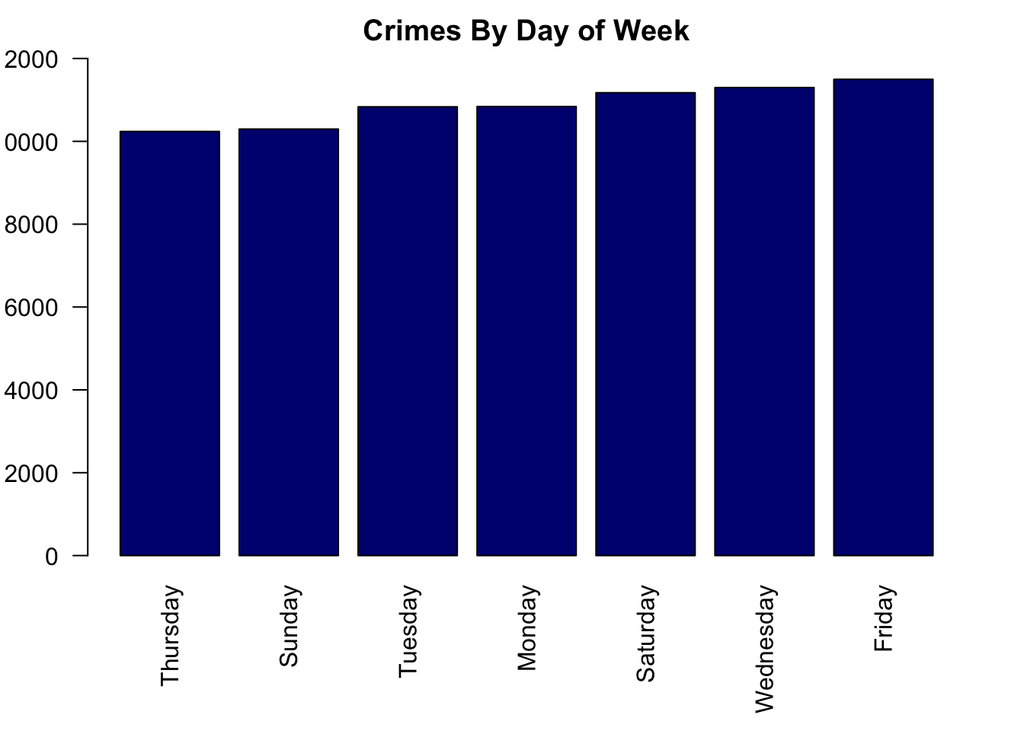

```r
par(las=2,mar=c(6,3,2,2))
barplot(sort(table(rawData$DayOfWeek)), ylim = c(0, 12000), col="navy", main="Crimes By Day of Week")
```

#### Number of daily assaults

```r
table(rawData$DayOfWeek[rawData$Category=="ASSAULT"])
```

```
##
##    Friday    Monday  Saturday    Sunday  Thursday   Tuesday Wednesday
##       959       889       999      1025       890       857       934
```

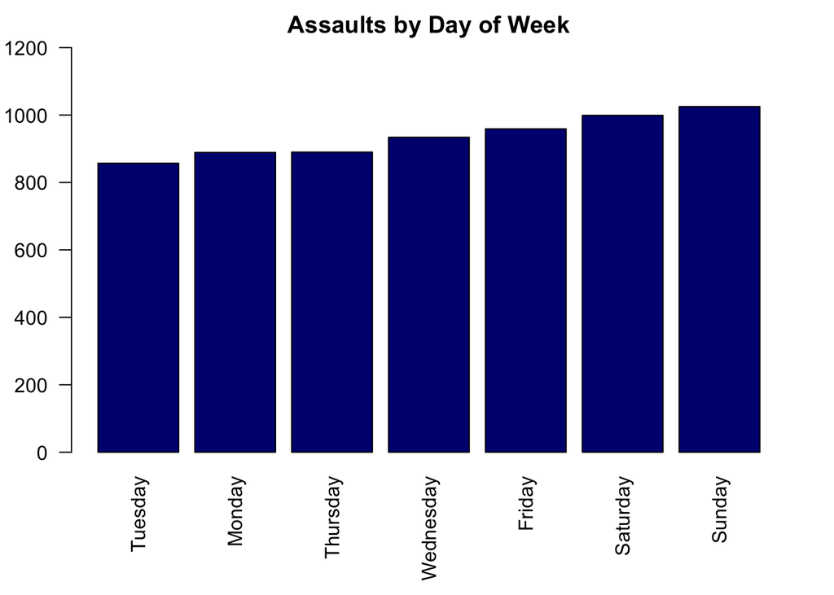

```r
par(las=2,mar=c(6,3,2,2))
barplot(sort(table(rawData$DayOfWeek[rawData$Category=="ASSAULT"])),col = "navy",ylim = c(0, 1200), main="Assaults by Day of Week")
```

### Hourly Assault Rate

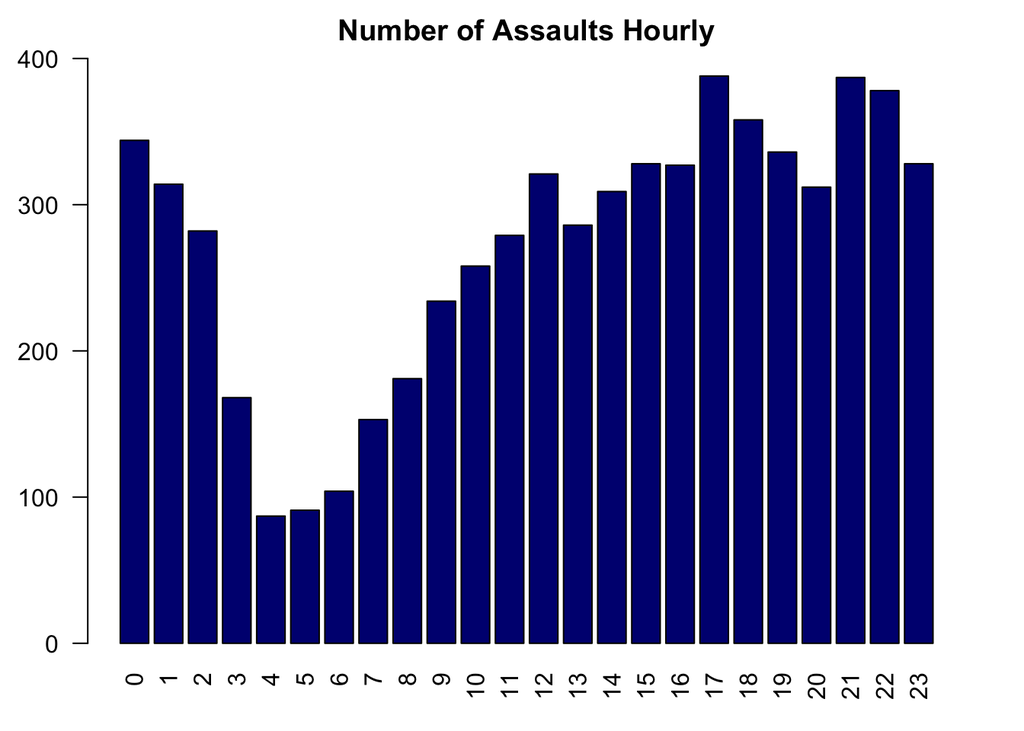

```r
par(las=2,mar=c(3,3,2,2))
barplot(table(rawData$HourOnly[rawData$Category=="ASSAULT"]),col = "navy",ylim=c(0, 400), main="Number of Assaults Hourly", xlab="Hour of the day")
```

### Monthly Assault Rate

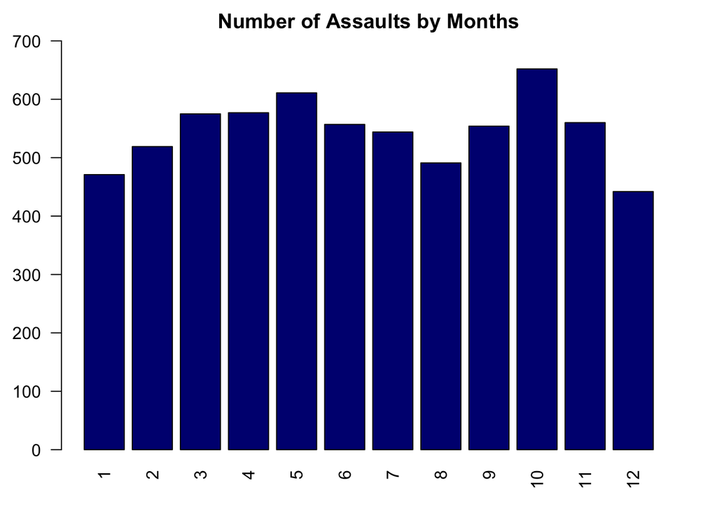

```r
par(las=2,mar=c(3,3,2,2))
barplot(table(rawData$MonthOnly[rawData$Category=="ASSAULT"]),col = "navy",ylim=c(0,700), main="Number of Assaults by Months", xlab="Month of the year")
```

### Monthly Robbery Rate

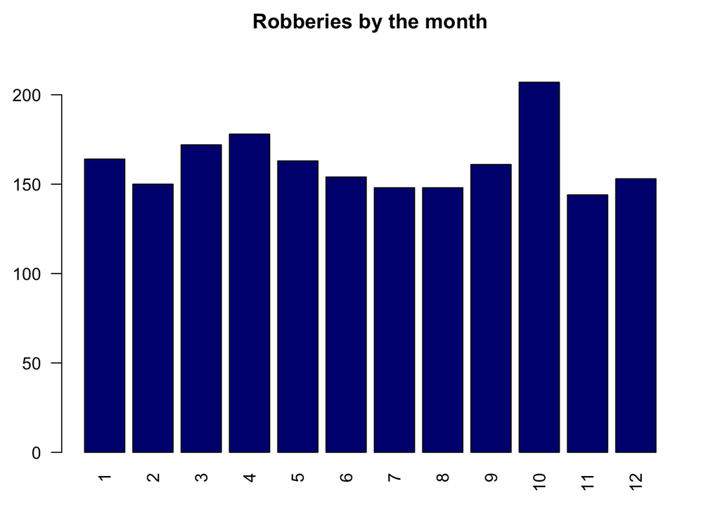

```r
par(las=2,mar=c(3,3,2,2))
barplot(table(rawData$MonthOnly[rawData$Category=="ROBBERY"]),col = "Navy",ylim=c(0,230), main="Robberies by the month")
```

### Grouping Assaults by Police District

```r
summary(rawData$PdDistrict)
```

```
##    BAYVIEW    CENTRAL  INGLESIDE    MISSION   NORTHERN       PARK
##       6891       9296       6618       9298       9458       4436
##   RICHMOND   SOUTHERN    TARAVAL TENDERLOIN
##       4342      14767       5536       5533
```

```r
table(rawData$PdDistrict[rawData$Category=="ASSAULT"])
```

```
##
##    BAYVIEW    CENTRAL  INGLESIDE    MISSION   NORTHERN       PARK
##        797        695        691       1021        725        281
##   RICHMOND   SOUTHERN    TARAVAL TENDERLOIN
##        220       1062        417        644
```

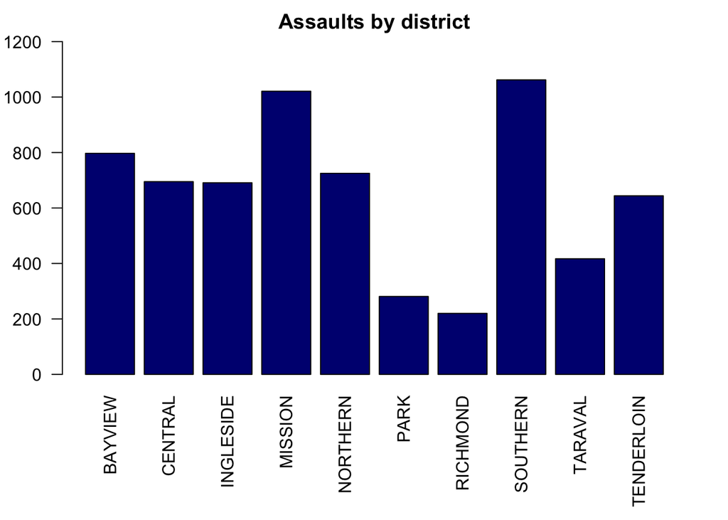

```r
par(las=2,mar=c(7,3,2,2))
plot(rawData$PdDistrict[rawData$Category=="ASSAULT"],ylim=c(0,1200), pch=19, main="Assaults by district", col = "navy")
```

# HeatMap Setup

```r
dat = rawData
map.df <- fortify(SFMap)
centers <- SpatialPointsDataFrame(gCentroid(SFMap, byid=TRUE), SFMap@data, match.ID=FALSE)
centDF = as.data.frame(centers)
centroids <- gCentroid(SFMap, byid=TRUE)
```

## Some data cleaning for Heat Map

```r
Hours <- format(as.POSIXct(strptime(dat$Dates,"%m/%d/%Y %H:%M",tz="")) ,format = "%H:%M")
HourOnly <- format(as.POSIXct(strptime(dat$Dates,"%m/%d/%Y %H:%M",tz="")) ,format = "%H")
MonthOnly <- format(as.POSIXct(strptime(dat$Dates,"%m/%d/%Y %H:%M",tz="")) ,format = "%m")
dat["HourOnly"] = NA
dat$HourOnly=as.numeric(HourOnly)
dat["MonthOnly"] = NA
dat$MonthOnly=as.numeric(MonthOnly)
dat["IsViolent"] = NA
dat$IsViolent = ifelse(dat$Category=="ASSAULT"
                       |dat$Category=="SEX OFFENSES FORCIBLE"
                       |dat$Category=="ROBBERY"
                       |dat$Category=="KIDNAPPING", 1, 0)
```

### HeatMap of Total crime in San Francisco, May 2014 -> May 2015

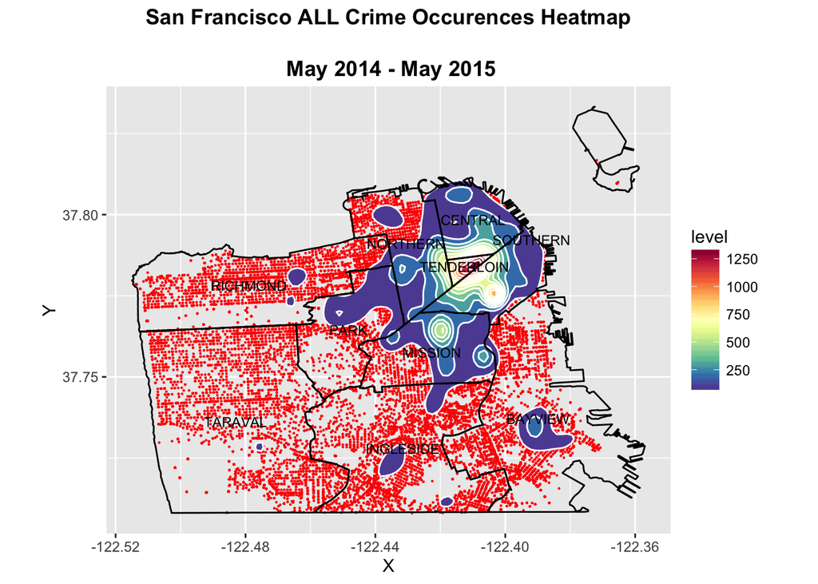

```r
#all crime heatmap
ggplot(dat, aes(x=X, y=Y))  + geom_point(colour="red", size = 0.1)  + stat_density2d(aes(fill = ..level..), alpha=1, geom="polygon")+ scale_fill_gradientn(colours=rev(brewer.pal(11,"Spectral"))) + coord_fixed() + geom_path(data=map.df,aes(x=long, y=lat,group=group), colour="black") + geom_text(data=centDF, mapping=aes(x=x, y=y, label=district), size=3, vjust=0.5, hjust=0.5) + ggtitle("San Francisco ALL Crime Occurences Heatmap\n May 2014 - May 2015") + theme(plot.title = element_text(lineheight=2, face="bold"))
```

### HeatMap of all VIOLENT crime in San Francisco, May 2014 -> May 2015

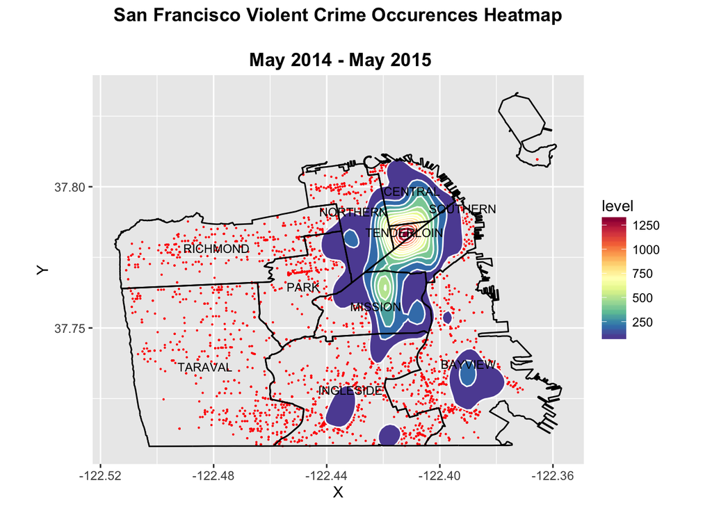

```r
#violent crimes heatmap
ggplot(dat[dat$IsViolent == 1,], aes(x=X, y=Y))  + geom_point(colour="red", size = 0.1)  + stat_density2d(aes(fill = ..level..), alpha=1, geom="polygon")+ scale_fill_gradientn(colours=rev(brewer.pal(11,"Spectral"))) + coord_fixed() + geom_path(data=map.df,aes(x=long, y=lat,group=group), colour="black") + geom_text(data=centDF, mapping=aes(x=x, y=y, label=district), size=3, vjust=0.5, hjust=0.5) + ggtitle("San Francisco Violent Crime Occurences Heatmap\n May 2014 - May 2015") + theme(plot.title = element_text(lineheight=2, face="bold"))
```

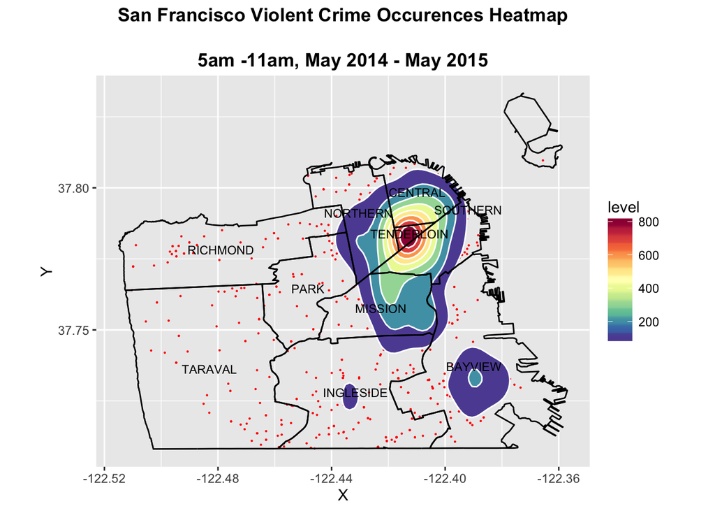

```r
#5am - 11am Heatmap Violent Crimes
ggplot(dat[(dat$IsViolent == 1 & dat$HourOnly > 5 & dat$HourOnly < 11),], aes(x=X, y=Y)) + geom_point(colour="red", size = 0.1)  + scale_fill_gradientn(colours=rev(brewer.pal(11,"Spectral"))) + stat_density2d(aes(fill = ..level..), alpha=1, geom="polygon") + coord_fixed() + geom_path(data=map.df,aes(x=long, y=lat,group=group), colour="black") + geom_text(data=centDF, mapping=aes(x=x, y=y, label=district), size=3, vjust=0.5, hjust=0.5) + ggtitle("San Francisco Violent Crime Occurences Heatmap\n5am -11am, May 2014 - May 2015") + theme(plot.title = element_text(lineheight=2, face="bold"))
```

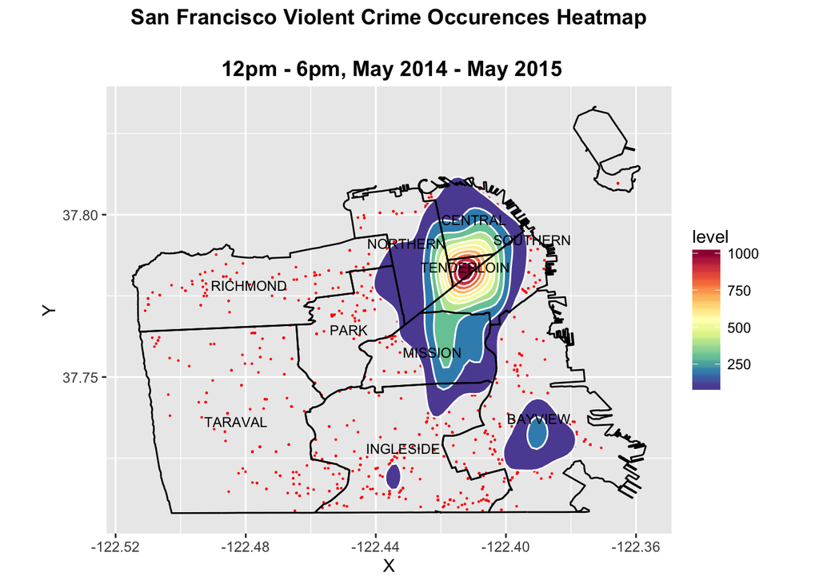

```r
#1200-1800 Heatmap Violent Crimes
ggplot(dat[(dat$IsViolent == 1 & dat$HourOnly > 12 & dat$HourOnly < 18),], aes(x=X, y=Y))  + geom_point(colour="red", size = 0.1) + stat_density2d(aes(fill = ..level..), alpha=1, geom="polygon") + scale_fill_gradientn(colours=rev(brewer.pal(11,"Spectral"))) + coord_fixed() + geom_path(data=map.df,aes(x=long, y=lat,group=group), colour="black") + geom_text(data=centDF, mapping=aes(x=x, y=y, label=district), size=3, vjust=0.5, hjust=0.5) + ggtitle("San Francisco Violent Crime Occurences Heatmap\n 12pm - 6pm, May 2014 - May 2015") + theme(plot.title = element_text(lineheight=2, face="bold"))
```

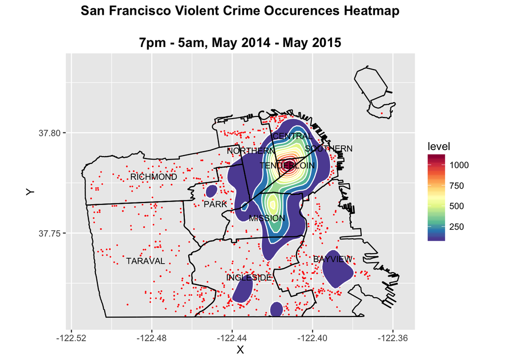

```r
ggplot(dat[(dat$IsViolent == 1 & (dat$HourOnly > 19 | dat$HourOnly < 5)),], aes(x=X, y=Y))  + geom_point(colour="red", size = 0.1) + stat_density2d(aes(fill = ..level..), alpha=1, geom="polygon") + scale_fill_gradientn(colours=rev(brewer.pal(11,"Spectral"))) + coord_fixed() + geom_path(data=map.df,aes(x=long, y=lat,group=group), colour="black") + geom_text(data=centDF, mapping=aes(x=x, y=y, label=district), size=3, vjust=0.5, hjust=0.5) + ggtitle("San Francisco Violent Crime Occurences Heatmap\n7pm - 5am, May 2014 - May 2015") + theme(plot.title = element_text(lineheight=2, face="bold"))
```

# Data Modeling Section

### Creating Split Function

```r
split_data = function(dat, frac=c(0.75, 0.25)) {

  k = length(frac)
  stopifnot(k > 0)

  n = nrow(dat)
  frac = frac/(sum(frac))
  starts = c(1, round(cumsum(frac) * n)[-k])
  ends = c(starts[-1]-1,n)
  samp = sample(1:n)
  data_sets = list()
  for (i in 1:k) {
    data_sets[[i]] = dat[samp[starts[i]:ends[i]],]
  }
  return(data_sets)
}
```

### Spliting the date into training and test datesets

```r
set.seed(132)
split = split_data(rawData)
tr_dat = split[[1]]
te_dat = split[[2]]
```

## Naïve Bayes

Using train data to make the model and using test data to see how acurate it is

```r
fit = naiveBayes(IsViolent ~ ., data=tr_dat)
predicts = predict(fit, newdata=te_dat)
conf_mtx = table(predicts, te_dat$IsViolent)
```

confusion matrix and accuracy of the model

```r
mean(predicts == te_dat$IsViolent)
```

```
## [1] 0.9643476
```

```r
conf_mtx
```

```
##
## predicts     nonViolent violent
##   nonViolent      16069       2
##   violent           677    2297
```

## Calculating Crime Index

### Crime Index will be based on District, Day of week, hour of day and if it is violent.

```r
df = data.frame(table(rawData$PdDistrict, rawData$DayOfWeek, rawData$HourOnly))
quantile(df$Freq,probs=seq(0,1,length.out=20))
```

```
##        0% 5.263158% 10.52632% 15.78947% 21.05263% 26.31579% 31.57895%
##   0.00000  10.00000  13.00000  17.00000  21.00000  25.00000  29.00000
## 36.84211% 42.10526% 47.36842% 52.63158% 57.89474% 63.15789% 68.42105%
##  32.57895  35.00000  39.00000  42.00000  45.00000  49.00000  53.00000
## 73.68421% 78.94737% 84.21053% 89.47368% 94.73684%      100%
##  58.00000  64.00000  71.00000  82.00000  98.00000 193.00000
```

```r
ViolentDF = data.frame(table(rawData$PdDistrict[rawData$IsViolent=="violent"], rawData$DayOfWeek[rawData$IsViolent=="violent"], rawData$HourOnly[rawData$IsViolent=="violent"]))
tempCrimeData = data.frame(table(rawData$PdDistrict[rawData$IsViolent=="nonViolent"], rawData$DayOfWeek[rawData$IsViolent=="nonViolent"], rawData$HourOnly[rawData$IsViolent=="nonViolent"]))

ViolentDF["WeightedFreq"]  = NA
tempCrimeData["WeightedFreq"]  = NA
tempCrimeData["ViolentWeighted"] =NA
tempCrimeData["Combined"] =NA
tempCrimeData["CrimeIndex"] =NA
df["WeightedFreq"]  = NA

ViolentDF["WeightedFreq"] = ViolentDF$Freq*.7
tempCrimeData["WeightedFreq"] = tempCrimeData$Freq*.3
tempCrimeData$ViolentWeighted = ViolentDF$WeightedFreq
tempCrimeData$ViolentWeighted <- as.numeric(tempCrimeData$ViolentWeighted )
tempCrimeData$WeightedFreq <- as.numeric(tempCrimeData$WeightedFreq)
tempCrimeData$Combined = tempCrimeData$ViolentWeighted + tempCrimeData$WeightedFreq
tempCrimeData$CrimeIndex = tempCrimeData$Combined / 62.3

crimeIndexData = data.frame(tempCrimeData$Var1, tempCrimeData$Var2, tempCrimeData$Var3, tempCrimeData$CrimeIndex)

names(crimeIndexData) <- c("PdDistrict", "DayOfWeek", "HourOnly", "CrimeIndex")
View(crimeIndexData)
```

## Linear Model using Crime Index

```r
fit = lm(CrimeIndex ~ .,data=crimeIndexData)

summary(fit)
```

```
##
## Call:
## lm(formula = CrimeIndex ~ ., data = crimeIndexData)
##
## Residuals:
##      Min       1Q   Median       3Q      Max
## -0.30545 -0.04792 -0.00160  0.04419  0.39901
##
## Coefficients:
##                       Estimate Std. Error t value Pr(>|t|)
## (Intercept)           0.293389   0.012155  24.137  < 2e-16 ***
## PdDistrictCENTRAL     0.067979   0.008704   7.810 1.01e-14 ***
## PdDistrictINGLESIDE  -0.009086   0.008704  -1.044  0.29671
## PdDistrictMISSION     0.085884   0.008704   9.867  < 2e-16 ***
## PdDistrictNORTHERN    0.072050   0.008704   8.277 2.58e-16 ***
## PdDistrictPARK       -0.095248   0.008704 -10.942  < 2e-16 ***
## PdDistrictRICHMOND   -0.100311   0.008704 -11.524  < 2e-16 ***
## PdDistrictSOUTHERN    0.243943   0.008704  28.025  < 2e-16 ***
## PdDistrictTARAVAL    -0.056763   0.008704  -6.521 9.27e-11 ***
## PdDistrictTENDERLOIN -0.042823   0.008704  -4.920 9.54e-07 ***
## DayOfWeekMonday      -0.016178   0.007283  -2.221  0.02645 *
## DayOfWeekSaturday    -0.005217   0.007283  -0.716  0.47390
## DayOfWeekSunday      -0.023214   0.007283  -3.188  0.00146 **
## DayOfWeekThursday    -0.029381   0.007283  -4.034 5.73e-05 ***
## DayOfWeekTuesday     -0.017523   0.007283  -2.406  0.01623 *
## DayOfWeekWednesday   -0.005919   0.007283  -0.813  0.41649
## HourOnly1            -0.100138   0.013485  -7.426 1.79e-13 ***
## HourOnly2            -0.121876   0.013485  -9.038  < 2e-16 ***
## HourOnly3            -0.182917   0.013485 -13.565  < 2e-16 ***
## HourOnly4            -0.219101   0.013485 -16.248  < 2e-16 ***
## HourOnly5            -0.227838   0.013485 -16.896  < 2e-16 ***
## HourOnly6            -0.206673   0.013485 -15.326  < 2e-16 ***
## HourOnly7            -0.156409   0.013485 -11.599  < 2e-16 ***
## HourOnly8            -0.102201   0.013485  -7.579 5.79e-14 ***
## HourOnly9            -0.064825   0.013485  -4.807 1.67e-06 ***
## HourOnly10           -0.044348   0.013485  -3.289  0.00103 **
## HourOnly11           -0.031828   0.013485  -2.360  0.01838 *
## HourOnly12            0.042765   0.013485   3.171  0.00155 **
## HourOnly13           -0.018230   0.013485  -1.352  0.17661
## HourOnly14           -0.001903   0.013485  -0.141  0.88778
## HourOnly15            0.027769   0.013485   2.059  0.03963 *
## HourOnly16            0.040335   0.013485   2.991  0.00282 **
## HourOnly17            0.077413   0.013485   5.741 1.12e-08 ***
## HourOnly18            0.100092   0.013485   7.422 1.84e-13 ***
## HourOnly19            0.064779   0.013485   4.804 1.70e-06 ***
## HourOnly20            0.040770   0.013485   3.023  0.00254 **
## HourOnly21            0.036207   0.013485   2.685  0.00733 **
## HourOnly22            0.028342   0.013485   2.102  0.03573 *
## HourOnly23           -0.005068   0.013485  -0.376  0.70711
## ---
## Signif. codes:  0 '***' 0.001 '**' 0.01 '*' 0.05 '.' 0.1 ' ' 1
##
## Residual standard error: 0.07978 on 1641 degrees of freedom
## Multiple R-squared:  0.7574, Adjusted R-squared:  0.7518
## F-statistic: 134.9 on 38 and 1641 DF,  p-value: < 2.2e-16
```

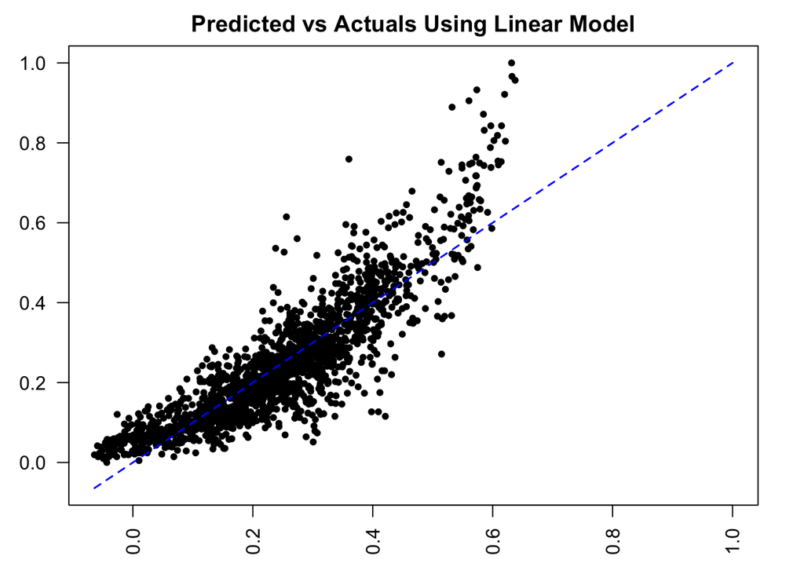

```r
predicted = predict(fit)
actual = crimeIndexData$CrimeIndex

rng = range(c(predicted, actual))
par(las=2,mar=c(3,3,2,2))
plot(predicted, actual, pch=20, xlim=rng, ylim=rng, xlab="predicted", ylab="actual", main = "Predicted vs Actuals Using Linear Model")
lines(c(rng[1], rng[2]), c(rng[1], rng[2]), lty=2, col="blue", lwd=1.5)
```

## Logistic Regression Model using Crime Index

```r
fit = glm(CrimeIndex ~ .,data=crimeIndexData, family = binomial)
summary(fit)
```

```
##
## Call:
## glm(formula = CrimeIndex ~ ., family = binomial, data = crimeIndexData)
##
## Deviance Residuals:
##      Min        1Q    Median        3Q       Max
## -0.64773  -0.10528  -0.00807   0.08654   0.88135
##
## Coefficients:
##                       Estimate Std. Error z value Pr(>|z|)
## (Intercept)          -0.874854   0.353074  -2.478 0.013219 *
## PdDistrictCENTRAL     0.367058   0.254544   1.442 0.149297
## PdDistrictINGLESIDE  -0.053707   0.265293  -0.202 0.839570
## PdDistrictMISSION     0.456138   0.252951   1.803 0.071346 .
## PdDistrictNORTHERN    0.387527   0.254159   1.525 0.127323
## PdDistrictPARK       -0.659735   0.292232  -2.258 0.023972 *
## PdDistrictRICHMOND   -0.703443   0.294812  -2.386 0.017029 *
## PdDistrictSOUTHERN    1.178263   0.247454   4.762 1.92e-06 ***
## PdDistrictTARAVAL    -0.362534   0.277092  -1.308 0.190755
## PdDistrictTENDERLOIN -0.266786   0.273037  -0.977 0.328517
## DayOfWeekMonday      -0.094447   0.220620  -0.428 0.668579
## DayOfWeekSaturday    -0.030080   0.219212  -0.137 0.890856
## DayOfWeekSunday      -0.136651   0.221599  -0.617 0.537461
## DayOfWeekThursday    -0.174256   0.222511  -0.783 0.433548
## DayOfWeekTuesday     -0.102455   0.220802  -0.464 0.642639
## DayOfWeekWednesday   -0.034156   0.219298  -0.156 0.876229
## HourOnly1            -0.579446   0.410956  -1.410 0.158542
## HourOnly2            -0.731359   0.421466  -1.735 0.082692 .
## HourOnly3            -1.256313   0.470205  -2.672 0.007544 **
## HourOnly4            -1.695433   0.529282  -3.203 0.001359 **
## HourOnly5            -1.828752   0.551227  -3.318 0.000908 ***
## HourOnly6            -1.527391   0.504406  -3.028 0.002461 **
## HourOnly7            -1.005700   0.444334  -2.263 0.023612 *
## HourOnly8            -0.593317   0.411857  -1.441 0.149701
## HourOnly9            -0.356689   0.397996  -0.896 0.370139
## HourOnly10           -0.237952   0.392173  -0.607 0.544015
## HourOnly11           -0.168374   0.389086  -0.433 0.665202
## HourOnly12            0.211258   0.376102   0.562 0.574317
## HourOnly13           -0.095060   0.386083  -0.246 0.805515
## HourOnly14           -0.009766   0.382898  -0.026 0.979651
## HourOnly15            0.138812   0.378105   0.367 0.713525
## HourOnly16            0.199623   0.376409   0.530 0.595880
## HourOnly17            0.373250   0.372373   1.002 0.316172
## HourOnly18            0.476021   0.370525   1.285 0.198889
## HourOnly19            0.314955   0.373598   0.843 0.399210
## HourOnly20            0.201711   0.376354   0.536 0.591985
## HourOnly21            0.179772   0.376947   0.477 0.633421
## HourOnly22            0.141612   0.378024   0.375 0.707950
## HourOnly23           -0.026082   0.383482  -0.068 0.945774
## ---
## Signif. codes:  0 '***' 0.001 '**' 0.01 '*' 0.05 '.' 0.1 ' ' 1
##
## (Dispersion parameter for binomial family taken to be 1)
##
##     Null deviance: 228.584  on 1679  degrees of freedom
## Residual deviance:  44.529  on 1641  degrees of freedom
## AIC: 1099.5
##
## Number of Fisher Scoring iterations: 5
```

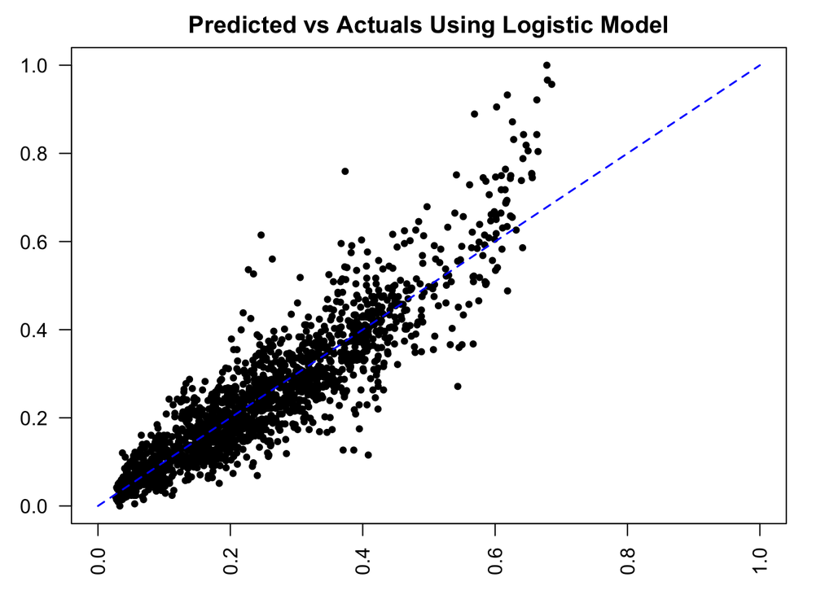

```r
predicted = predict(fit, type = "response")
actual = crimeIndexData$CrimeIndex

rng = range(c(predicted, actual))
par(las=2,mar=c(3,3,2,2))
plot(predicted, actual, pch=20, xlim=rng, ylim=rng, xlab="predicted", ylab="actual", main = "Predicted vs Actuals Using Logistic Model")
lines(c(rng[1], rng[2]), c(rng[1], rng[2]), lty=2, col="blue", lwd=1.5)
```

## Regression Tree Model using Crime Index

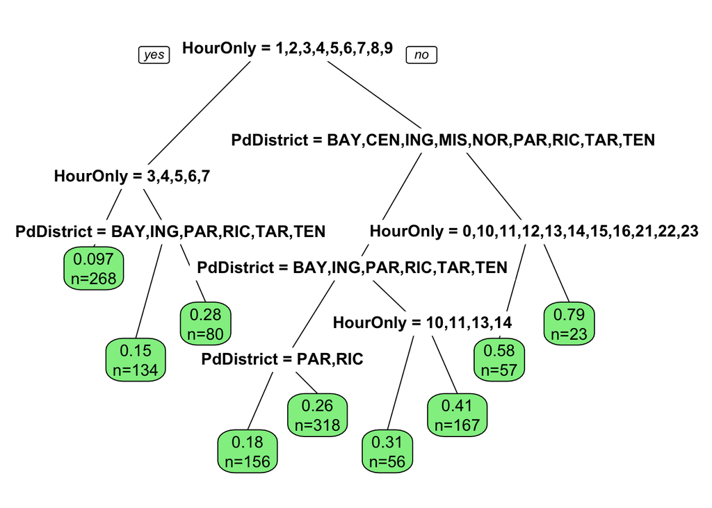

```r
set.seed(132)
split = split_data(crimeIndexData)
tr_dat = split[[1]]
te_dat = split[[2]]

fit = rpart(CrimeIndex ~ ., data=tr_dat)

prp(fit, extra=1, varlen=-10, box.col="lightgreen")
```

```r
predicted = predict(fit, te_dat)
errors = te_dat$CrimeIndex - predicted
rmse = sqrt(mean(errors^2))
```